# Why did we create this page?

2021-03-16

## **About us?**

> We are David Vanegas and Eduardo Grajales, two **biologists** from the University of Quindío passionate about the world of programming and R

Likewise, we are interested in science directed towards conservation, ecotourism and environmental education, as promoters of a society in favor of sustainable development focused on the well-being of the communities in their territories. We are committed to a society that generates ideas and projects that are based on information obtained from basic science, so that it allows us to make good decisions about our natural resources and their ecosystem services, especially in a country as rich in biodiversity as Colombia.

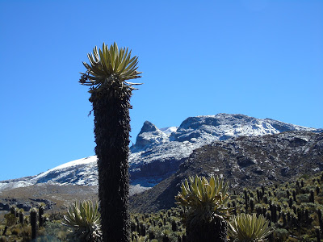

Photograph taken at the PNNN of Colombia, Frailejón (*Espeletia hartwegiana*) in the snowy Santa Isabel, Santa Rosa de Cabal-Risaralda

#### **Why do we create R Biologists?**

This space is initially created by the need that we observe while developing our undergraduate (or was the undergraduate developing us? It is a question that we do not know if it has an answer, is that clear?). Many times after one or another late night or early morning, we asked ourselves: Why does everyone talk about Software R? Why do some people talk so badly about it? and Why do other people speak wonders? Is it really so necessary to be a professional?

> Fun fact: they spoke more badly than good. The bad words and moans of emotional pain were always heard, some say that they dreamed of him and that he made life loops with such condition.

Already having these questions in mind, it must be said that independently we were very hooked on the subject of programming and the use of R, however, there was a challenge to take on and that was: to See what this R guy is about! You had to look at it directly at the pixels and say, I’m not afraid of you! Because the gossip said that that “thing” read need and fear, because when you needed it most, more problems it had, it resembles a printer.

Thus, deliberately searching, googling, we realized that there is a lot of information (which we hope to be able to organize in this blog), one does not know where to start, information that was mostly in English, so HOLD ON! If you **DO NOT** have any command of English, then we are going to give you a small recommendation: Go to the loneliest corner of your house or block of the university and follow the next image instructions

[figure not shown]

But one thinks: “nah it can’t be that bad …” and well it could actually get worse, if one needs to learn hard because the diversity report and accumulation curves have to be delivered for tomorrow or rather for today because It’s already one in the morning (that’s what they told us, it never happened to us), and if that report doesn’t look good, one loses a laboratory and if one loses a laboratory, one loses matter and thus begins to unleash a series of terrifying thoughts that we don’t even want to remember.

But hey, calm down that we have already encouraged your little idea to read in English and we will try to ensure that the relationship you are going to have with R is not as toxic as a glass of water flavored with mercury is.

Thanks to Eliana Tabares for her review

[figure not shown]